# 5 Languages in 30 minutes 1/5: Python

Bas Bossink

2019-04-16

# Introduction

# Why series?

- Short
- Interesting?
- Broaden horizon
- [Stackoverflow developer survey 2019](https://insights.stackoverflow.com/survey/2019)

# Python

# Why Python?

# What is Python

- Interpreted
- Multi-paradigm:
  - Imperative
  - Object oriented
  - Functional
  - Aspect oriented
  - Metaprogramming
- Strongly, dynamically typed
- Garbage collected
- Scripting language
- Batteries included
- Significant whitespace
- Easily extendable
- Embeddable

# Implementations

- CPython
- Jython (on the JVM)
- IronPython (on .NET)
- PyPy (fast, JIT compiled)
- Stackless (microthreads)
- MicroPython (running on microcontrollers)

# History

- Born: 1990
  - Amsterdam (CWI)
  - Guido van Rossum
- Goals:
  - It should be an easy and intuitive language, just as powerful as major competitors.
  - It should be open source, so anyone can contribute to its development.
  - Its code should be understandable as plain English.
  - It should be suitable for everyday tasks, allowing for short development times.
- 16 October 2000: Python 2.0
- 3 December 2008: Python 3.0
- current:
  - 3.7.3
  - 2.7.16

# The Zen of Python

- Beautiful is better than ugly
- Explicit is better than implicit
- Simple is better than complex
- Complex is better than complicated
- Readability counts
- …

# In Practice (1/2)

- REPL: Read Eval Print Loop
- python version manager: pyenv (anaconda)
- package manager: pip (176,172 packages)
- very large standard library included:
  - http server

    ```
    python -m SimpleHTTPServer 8000
    ```

  - smtp server

    ```
    python -m smtpd -n -c DebuggingServer 127.0.0.1:10025
    ```

  - csv parser
  - fractions
  - asyncio
  - unittest
  - doctest
- very portable (Windows, MacOS, Linux, BSD's)

# In Practice (2/2)

- PEP: Python Enhancement Proposal
- Documentation: doc strings, Sphinx
- IDE's:
  - PyCharm (Jetbrains)
  - IDLE (included)
  - every decent editor
- also for GUI's:
  - PyQt
  - PyGtk
  - WxPython
- cloud:
  - one of the original google cloud platform languages
  - available on AWS, and Azure

# Notable features

- Multiple assignment
- Slices
1. List comprehensions

   ```python
   a = [x**2 for x in range(5)]
   print(a)
   ```

   ```
   [0, 1, 4, 9, 16]
   ```

# Notable libraries

1. Numpy, SciPy

   ```python
   import numpy as np
   a = np.random.random(4).reshape(2,2)
   print("a :\n", a)
   print("a' :\n", a.transpose())
   ```

   ```
   a :
    [[0.71257844 0.92661164]
    [0.81012854 0.94959446]]
   a' :
    [[0.71257844 0.81012854]
    [0.92661164 0.94959446]]
   ```

# Notable libraries

1. Matplotlib

   ```python
   import matplotlib.pyplot as plt
   import numpy as np
   plt.rc('text', usetex=True)
   plt.rc('font', family='sans serif')
   x = np.linspace(-15, 15, 500)
   plt.xlabel(r'$x$')
   plt.ylabel(r'$y$')
   plt.plot(x, np.sin(x)/x, label=r'$y = \frac{\sin (x)}{x}$')
   plt.grid(True)
   axis = plt.gca()
   axis.legend()
   plt.tight_layout(0)
   plt.savefig('images/python-matplot-fig.png', dpi=600)
   ```

# Result

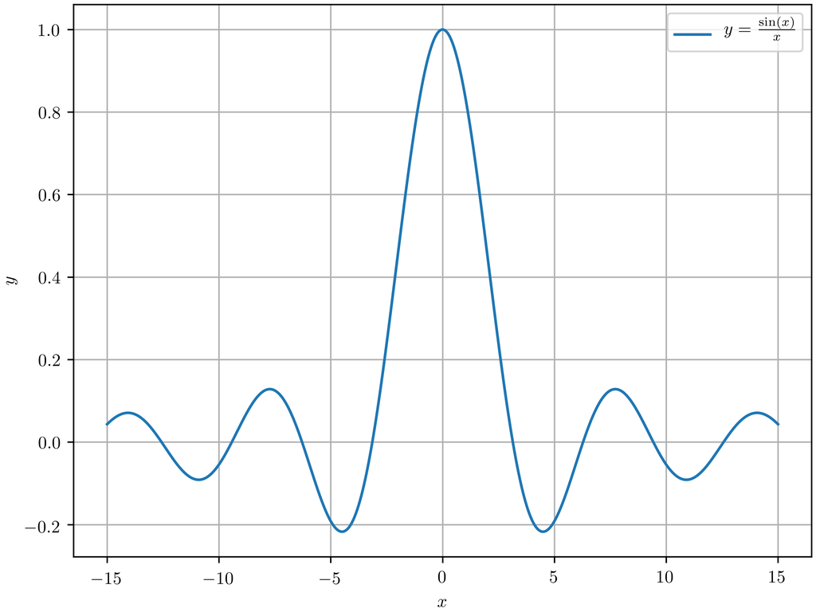

# Notable libraries

- Scikit-Learn (Machine learning)
- TensorFlow (Machine learning)
- Gym (Reinforcement learning)
- Django (CMS)
- Flask (Web framework)
- Twisted (event-driven network programming)

# Usages

- Scientific computing
- Extension language
  - GIMP
  - Inkscape
  - GNU Debugger
  - Blender
- Web Apps
- Machine learning
- Installer (Ubiquity, Anaconda)
- Software development:
  - SCons
  - Buildbot
  - robotframework
  - cookiecutter

# Rusty washers

- Performance, options
  - use native libraries if needed
  - PyPy
- 2.x vs 3.x

# Resources

- [Python.org](https://www.python.org/)
- [Official documentation](https://www.python.org/doc/)
- [The Zen of Python](https://www.python.org/dev/peps/pep-0020/)
- [Python Package Index](https://pypi.org/)
- [Sphinx documentation generator](http://www.sphinx-doc.org/en/master/)
- [Anaconda](https://www.anaconda.com/distribution/) scientific computing distribution
- [Python Beginners Guide](https://wiki.python.org/moin/BeginnersGuide)
- [Python Programming Wikibook](https://en.wikibooks.org/wiki/Python_Programming)
- [Pluralsight courses](https://www.pluralsight.com/search?q=Python)
- [IPython, better REPL](https://ipython.org/)
- [Thonny beginner freindly IDE](https://thonny.org/)
- [PyCharm](https://www.jetbrains.com/pycharm/) Jetbrains IDE
- [Spyder Scientific Development Environment](https://www.spyder-ide.org/)
- [Python using VS Code](https://code.visualstudio.com/docs/languages/python)
- [Jupyter Notebooks](https://jupyter.org/)